# Forecasting # of visitors from Malaysia

## Smoothing by Linear Regression Model

```r
SLR_SI <- Linear_Regression_Seasonal_Index(Visitors, Quarter, Season)
cat("# # # # The Simple Linear_Regression seasonal index # # # ","\n")
```

```
# # # # The Simple Linear_Regression seasonal index # # #
```

```r
print(SLR_SI)
```

```
 [1] 0.6500699 0.9909126 1.2704281 1.0302993 0.9178450 0.8474208 0.6033841 0.7134724 0.9410086
[10] 1.0209013 1.3935149 1.6207430
```

### Forecast by seasonal index

```
### Linear Model ###
Call:
lm(formula = Des_x ~ t)

Residuals:
    Min      1Q  Median      3Q     Max
-9693.9 -2386.3  -173.5  2155.6 13626.0

Coefficients:
            Estimate Std. Error t value Pr(>|t|)
(Intercept) 19166.11     711.63   26.93   <2e-16 ***
t             240.10      10.34   23.23   <2e-16 ***
---
Signif. codes:  0 ‘***’ 0.001 ‘**’ 0.01 ‘*’ 0.05 ‘.’ 0.1 ‘ ’ 1

Residual standard error: 3922 on 118 degrees of freedom
Multiple R-squared:  0.8206,    Adjusted R-squared:  0.819
F-statistic: 539.6 on 1 and 118 DF,  p-value: < 2.2e-16


    Shapiro-Wilk normality test

data:  Standard_E
W = 0.9885, p-value = 0.4103

run test:[1] 0.1424388
The Outliers[1]  1  2 52 63 98
influential observations:[1] "no influential observations"
mean_y: 33452.34



deseasonalized data:
  [1]  9472.187 10550.838 14640.757 14366.357 17554.569 14840.807 16145.504 18389.714 18757.984
 [10] 20360.019 21014.964 23341.762 24036.737 28775.549 22650.580 22547.472 27583.171 24863.323
 [19] 24710.178 25077.388 24708.113 26311.099 23133.934 24530.737 25962.989 24989.945 25723.249
 [28] 32064.308 22775.563 24738.923 27560.524 26284.859 31747.357 27402.012 26570.571 27500.748
 [37] 29907.009 25687.355 26308.283 33625.686 26248.433 28842.160 30313.275 28185.222 26200.261
 [46] 29330.537 26558.764 28714.958 36493.089 27944.793 34414.231 45037.479 33081.527 37383.632
 [55] 37684.564 32714.009 32730.328 38613.899 36083.900 38039.434 39807.374 36659.472 43161.561
 [64] 28303.826 39286.571 37670.633 33380.340 36330.869 34084.029 28132.652 40509.180 35573.160
 [73] 33636.397 35251.670 39465.739 31184.106 38815.799 37250.416 36501.943 37700.611 35270.055
 [82] 39756.280 37379.526 39364.291 38394.281 35101.804 43367.068 33196.797 42814.700 41322.308
 [91] 39454.190 44275.374 43933.739 46169.560 43083.115 41668.476 44530.393 51752.327 38315.560
[100] 42333.801 40612.808 44502.831 43932.793 45116.346 48239.430 36697.484 47322.631 42664.303
[109] 41651.911 52633.825 38134.912 41190.098 40193.045 43625.175 46125.091 44709.742 44804.415
[118] 47976.985 44854.959 43274.806
```

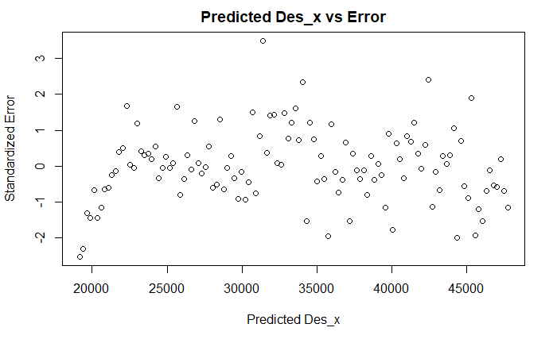

```r
Forecast_Visitors_SLR <- Forecast_by_SI(Visitors, Quarter, Season, SLR_SI, t)
```

```r
cat("# # # # The Forecast_Visitors_y # # # ","\n")
```

```
# # # # The Forecast_Visitors_y # # #
```

```r
print(Forecast_Visitors_SLR)
```

```
  [1] 17591.52 16445.23 11854.28 14188.42 18939.24 20792.32 28715.80 33787.38 13707.99 21133.25
 [11] 27399.52 22468.01 20236.07 18886.87 13592.78 16244.11 21650.52 23733.80 32730.87 38457.15
 [21] 15581.01 23988.32 31059.95 25436.56 22880.61 21328.51 15331.29 18299.81 24361.81 26675.28
 [31] 36745.95 43126.93 17454.03 26843.39 34720.38 28405.12 25525.16 23770.14 17069.79 20355.51
 [41] 27073.10 29616.76 40761.02 47796.71 19327.05 29698.47 38380.81 31373.68 28169.71 26211.78
 [51] 18808.30 22411.21 29784.39 32558.24 44776.10 52466.48 21200.06 32553.54 42041.24 34342.23
 [61] 30814.26 28653.42 20546.80 24466.90 32495.67 35499.72 48791.17 57136.26 23073.08 35408.62
 [71] 45701.67 37310.79 33458.80 31095.05 22285.31 26522.60 35206.96 38441.20 52806.24 61806.04
 [81] 24946.10 38263.69 49362.10 40279.35 36103.35 33536.69 24023.81 28578.30 37918.25 41382.68
 [91] 56821.32 66475.81 26819.12 41118.76 53022.53 43247.91 38747.90 35978.33 25762.31 30634.00
[101] 40629.54 44324.16 60836.39 71145.59 28692.14 43973.84 56682.96 46216.46 41392.45 38419.97
[111] 27500.82 32689.69 43340.82 47265.64 64851.47 75815.37 30565.15 46828.91 60343.39 49185.02
[121] 31189.49 47780.60 61563.53 50174.54 44918.51 41675.48 29818.83 35430.62 46955.87 51187.61
[131] 70204.90 82041.74
```

```r
#write.csv(Forecast_Visitors_SLR,"../../temp.csv")
lines(t, Visitors, type="o", col = "blue")    #actual
lines(t2,Forecast_Visitors_SLR, type="o", col = "red")  #forecast
```

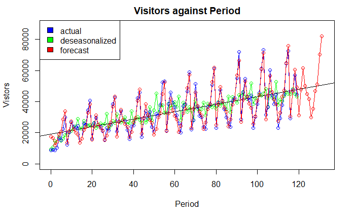

```r
legend("topleft", c("actual", "deseasonalized", "forecast"), fill=c("blue","green", "red"))
```

*Residual analysis:*  
1.normality test  
H0: Errors are normally distributed.  
H1: Errors are not normally distributed.  
Since pvalue = 0.4103 > 0.05, we do not reject H0.

2..Homoscedasticity & Heteroscedasticity  
H0: The variance of e is the same for all values of x.  
H1: The variance of e is not the same for all values of x.  
According to the plot, there is no sign of heteroscedasticity.

3.Dependence of the Error Variable  
H0 : Randomness exists.  
H1 : Randomness does not exist.  
Since pvalue = 0.1424> 0.05, we do not reject H0.

*Assessment*  
The standard error of estimate (3922) is samll compared to mean_y (33452.34). We can conclude that the model fit the data.

r^2 = 82.06% of the variation in the fund value is explained by the variation in Des_x. The rest(17.94%) remains unexplained by this model.

Testing the coefficients beta1.  
H0: beta1 = 0, H1: beta1 != 0  
Since p-value <2e-16 , we are 95% confident to reject H0. There is overwhelming evidence that t affects Des_x.

The # of visitors forecast for the next 12 months are 31189.49, 47780.60, 61563.53, 50174.54, 44918.51, 41675.48, 29818.83, 35430.62, 46955.87, 51187.61, 70204.90, 82041.74 respectively.

## Regression model by indicator variables

### The Regression Model

y = beta0 + beta1*t + beta2*Q1 + beta3*Q2 + beta4*Q3 + beta5*Q4 +beta6*Q5 +beta7*Q6 +beta8*Q7 +beta*9Q8 +beta10*Q9 +beta11*Q10 +vbeta12Q*11 +e where t = time in chronological order Qi = indicator variable (0, 1).

### Dummy as Quarter

```r
Dummy_I <- Season - 1    # n-1 indicator variables
Q <- matrix(nrow =n, ncol = Dummy_I)
Dummy_Name <- vector("character", length = Dummy_I)
for(i in 1:Dummy_I){
  Dummy_Name[i] <- paste0("Q", i)
}
colnames(Q) <- Dummy_Name
for(i in 1:n){
  for(j in 1:Dummy_I){
    if(Quarter[i] == j){
      Q[i,j] <- 1
    } else {
      Q[i,j] <- 0
    }
  }
}
```

### build the model

```r
Data.Visitors <- cbind(t, Q)  #t, Q1, Q2, Q3...
linearModelVar1 <- lm(Visitors ~ Data.Visitors)
cat("\n# # # # The regression model # # # ","\n")
```

```
# # # # The regression model # # #
```

```r
print(summary(linearModelVar1))
```

```
Call:
lm(formula = Visitors ~ Data.Visitors)

Residuals:
     Min       1Q   Median       3Q      Max
-12044.6  -2738.8     -1.9   3100.7  10478.2

Coefficients:
                  Estimate Std. Error t value Pr(>|t|)
(Intercept)       40156.86    1621.46  24.766  < 2e-16 ***
Data.Visitorst      241.83      12.09  19.997  < 2e-16 ***
Data.VisitorsQ1  -33016.73    2042.06 -16.168  < 2e-16 ***
Data.VisitorsQ2  -21626.45    2042.17 -10.590  < 2e-16 ***
Data.VisitorsQ3  -11611.88    2042.35  -5.686 1.14e-07 ***
Data.VisitorsQ4  -20363.90    2042.60  -9.970  < 2e-16 ***
Data.VisitorsQ5  -23487.12    2043.78 -11.492  < 2e-16 ***
Data.VisitorsQ6  -25547.65    2043.31 -12.503  < 2e-16 ***
Data.VisitorsQ7  -34017.77    2042.92 -16.652  < 2e-16 ***
Data.VisitorsQ8  -30835.10    2042.60 -15.096  < 2e-16 ***
Data.VisitorsQ9  -23226.72    2042.35 -11.373  < 2e-16 ***
Data.VisitorsQ10 -20220.25    2042.17  -9.901  < 2e-16 ***
Data.VisitorsQ11  -7870.97    2042.06  -3.854 0.000198 ***
---
Signif. codes:  0 ‘***’ 0.001 ‘**’ 0.01 ‘*’ 0.05 ‘.’ 0.1 ‘ ’ 1

Residual standard error: 4566 on 107 degrees of freedom
Multiple R-squared:  0.9025,    Adjusted R-squared:  0.8915
F-statistic:  82.5 on 12 and 107 DF,  p-value: < 2.2e-16
```

```r
cat(" ","\n")
```

```r
ANOVA_T_lm <- anova(linearModelVar1)
cat("# # # # The ANOVA Table # # # ","\n")
```

```
# # # # The ANOVA Table # # #
```

```r
print(ANOVA_T_lm)
```

```
Analysis of Variance Table

Response: Visitors
               Df     Sum Sq    Mean Sq F value    Pr(>F)
Data.Visitors  12 2.0642e+10 1720155928  82.504 < 2.2e-16 ***
Residuals     107 2.2309e+09   20849299
---
Signif. codes:  0 ‘***’ 0.001 ‘**’ 0.01 ‘*’ 0.05 ‘.’ 0.1 ‘ ’ 1
```

```r
#residual analysis
SE_1 <- standarized_errors_MR(Visitors, Data.Visitors)[,1]
h_1 <- standarized_errors_MR(Visitors, Data.Visitors)[,2]
D_1 <- standarized_errors_MR(Visitors, Data.Visitors)[,3]
print(shapiro.test(SE_1) )          # normality
```

```
    Shapiro-Wilk normality test

data:  SE_1
W = 0.99208, p-value = 0.7282
```

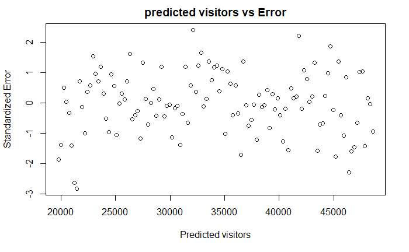

```r
b0<- coef(linearModelVar1)[1]             # Homoscedasticity & Heteroscedasticity
b1 <- coef(linearModelVar1)[2]
b2 <- coef(linearModelVar1)[3]
b3 <- coef(linearModelVar1)[4]
b4 <- coef(linearModelVar1)[5]
b5 <- coef(linearModelVar1)[6]
b6 <- coef(linearModelVar1)[7]
b7 <- coef(linearModelVar1)[8]
b8 <- coef(linearModelVar1)[9]
b9 <- coef(linearModelVar1)[10]
b10 <- coef(linearModelVar1)[11]
b11 <- coef(linearModelVar1)[12]
b12 <- coef(linearModelVar1)[13]
yhat <- vector("double", length = n)
for(i in 1:n) {
       yhat <- b0 + b1 *t + b2 *Q[i,1] + b3 *Q[i,2] + b4 *Q[i,3]+ b5 *Q[i,4]+ b6 *Q[i,5]+ b7 *Q[i,6]+ b8 *Q[i,7]+ b9 *Q[i,8]+ b10 *Q[i,9]+ b11 *Q[i,10]+ b12 *Q[i,11]
}
plot(x = yhat, y = SE_1, xlab = "Predicted visitors", ylab = "Standardized Error", main = "predicted visitors vs Error")
```

```r
cat("\nRun_Test:\n")
```

```
Run_Test:
```

```r
print(Run_Test(SE_1))              #errors are independent
```

```
[1] 0.06673393
```

```r
cat("\nThe Outliers\n")
```

```
The Outliers
```

```r
Outliers <- abs(SE_1) > 2
if(sum(Outliers)!=0){
    print(which(Outliers))
}else{
  print("no outliers")
}
```

```
[1]   7   8  52  92 111
```

```r
cat("\ninfluential observations:\n")
```

```
influential observations:
```

```r
k <- dim(Data.Visitors)[2]
Inf_Obs <- h_1 > 3*(k+1)/n
if(sum(Inf_Obs)!=0){
    print(which(Inf_Obs))
}else{
  print("no influential observations")
}
```

```
[1] "no influential observations"
```

```r
#assesment
cat("\nmean_y:",mean(Visitors),"\n")
```

```
mean_y: 33560.08
```

*Residual analysis:*  
1.normality test  
H0: Errors are normally distributed.  
H1: Errors are not normally distributed.  
Since pvalue = 0.7282 > 0.05, we do not reject H0.

2..Homoscedasticity & Heteroscedasticity  
H0: The variance of e is the same for all values of x.  
H1: The variance of e is not the same for all values of x.  
According to the plot, there is no sign of heteroscedasticity.

3.Dependence of the Error Variable  
H0 : Randomness exists.  
H1 : Randomness does not exist.  
Since pvalue = 0.0667 > 0.05, we do not reject H0.

*Assessment*  
The standard error of estimate (4566) is samll compared to mean_y (33560.08 ). We can conclude that the model fit the data.

The F-test of ANOVA: H0: beta1 = beta2 = … = beta11 = 0 H1: At least one betai is not equal to zero. ` since p-value < 2.2e-16 < 0.05, there is sufficient evidence to reject the null hypothesis. At least one of the betai is not equal to zero. Thus, at least one independent variable is related to y. This regression model is valid.

Testing of the Coefficients H0: betai = 0 H1: betai != 0 ` Since all the pvalue < 0.05, there is overwhelming evidence to infer that all the Qi and t affects # of visitors.

### Forecast

```r
NoB <- Dummy_I + 2  #b0 ,b1(t), b2(Q1), b3(Q2), b4(Q3)...
bi <- vector("double", length = NoB)
for(i in 1:NoB){
  bi[i] <- coef(linearModelVar1)[i]  #bi[1]:intercept, bi[2]: coefficient of t
}
b0 <- vector("double", length = n)
for(j in 1:n) {
    b0[j] <- 1
}
Data.Visitors_0 <- cbind(b0, Data.Visitors) # matrix[n*NoB]: each bi for all the n samples
y_Dummy <- c(Data.Visitors_0 %*% bi)     # bi[NoB*1]: 1 (*b0), t (*b1), 1or0 (*b2), 1or0 (*b3)...  #only 24 periods
#the next 12 months for
Q1 = bi[1] + bi[2]*120 + bi[3]
Q2 = bi[1] + bi[2]*121 + bi[4]
Q3 = bi[1] + bi[2]*122 + bi[5]
Q4 = bi[1] + bi[2]*123 + bi[6]
Q5 = bi[1] + bi[2]*124 + bi[7]
Q6 = bi[1] + bi[2]*125 + bi[8]
Q7 = bi[1] + bi[2]*126 + bi[9]
Q8 = bi[1] + bi[2]*127 + bi[10]
Q9 = bi[1] + bi[2]*128 + bi[11]
Q10 = bi[1] + bi[2]*129+ bi[12]
Q11 = bi[1] + bi[2]*130 + bi[13]
Q12 =  bi[1] + bi[2]*131   ###
y_Dummy = c(y_Dummy,Q1,Q2,Q3,Q4,Q5,Q6,Q7,Q8,Q9,Q10,Q11,Q12)  #28 periods total
cat("# # # # The Forecast_Visitors_y# # # ","\n")
```

```
# # # # The Forecast_Visitors_y# # #
```

```r
print(y_Dummy)
```

```
  [1] 16669.741 14851.041  6622.741 10047.241 17897.441 21145.741 33736.841 41849.641  9074.741
 [10] 20706.841 30963.241 22453.041 19571.643 17752.943  9524.643 12949.143 20799.343 24047.643
 [19] 36638.743 44751.543 11976.643 23608.743 33865.143 25354.943 22473.545 20654.845 12426.545
 [28] 15851.045 23701.245 26949.545 39540.645 47653.445 14878.545 26510.645 36767.045 28256.845
 [37] 25375.447 23556.747 15328.447 18752.947 26603.147 29851.447 42442.547 50555.347 17780.447
 [46] 29412.547 39668.947 31158.747 28277.349 26458.649 18230.349 21654.849 29505.049 32753.349
 [55] 45344.449 53457.249 20682.349 32314.449 42570.849 34060.649 31179.251 29360.551 21132.251
 [64] 24556.751 32406.951 35655.251 48246.351 56359.151 23584.251 35216.351 45472.751 36962.551
 [73] 34081.153 32262.453 24034.153 27458.653 35308.853 38557.153 51148.253 59261.053 26486.153
 [82] 38118.253 48374.653 39864.453 36983.055 35164.355 26936.055 30360.555 38210.755 41459.055
 [91] 54050.155 62162.955 29388.055 41020.155 51276.555 42766.355 39884.957 38066.257 29837.957
[100] 33262.457 41112.657 44360.957 56952.057 65064.857 32289.957 43922.057 54178.457 45668.257
[109] 42786.859 40968.159 32739.859 36164.359 44014.559 47262.859 59853.959 67966.759 35191.859
[118] 46823.959 57080.359 48570.159 36159.160 47791.260 58047.660 49537.460 46656.062 44837.362
[127] 36609.062 40033.562 47883.762 51132.062 63723.162 71835.962
```

```r
t2 = c(t,n,n+1,n+2,n+3,n+4,n+5,n+6,n+7,n+8,n+9,n+10,n+11)
plot(t,Visitors, col = "blue", main = "Visitors against Period", xlab = "Period", ylab = "Vistitors", xlim=range(t2, t2+1), ylim=range(y_Dummy,0))
lines(t, Visitors, type="o", col = "blue")    #actual
```

```r
lines(t2,y_Dummy, type="o", col = "red")  #forecast
abline(lm(Visitors ~ t))
```

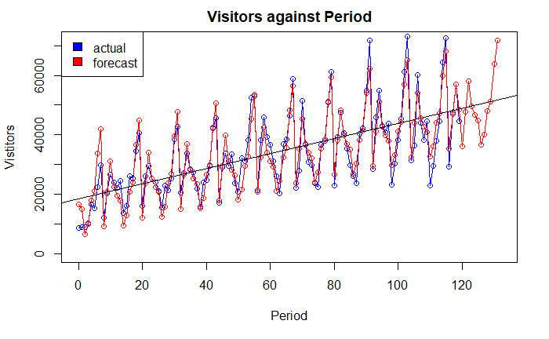

```r
legend("topleft", c("actual", "forecast"), fill=c("blue","red"))
```

The # of visitors forecast for the next 12 months are 36159.160, 47791.260, 58047.660, 49537.460, 46656.062, 44837.362, 36609.062, 40033.562, 47883.762, 51132.062, 63723.162, 71835.962.

## Error Metrics

```r
CMV_MAD <- Mean_Absolute_Deviation(Visitors, Forecast_Visitors_CMV, 1)  #actual y, predicted y
CMV_MSE <- Mean_Square_Error(Visitors, Forecast_Visitors_CMV, 1)
CMV_MAPE <- Mean_Absolute_Percentage_Error(Visitors, Forecast_Visitors_CMV, 1)
SLR_MAD <- Mean_Absolute_Deviation(Visitors, Forecast_Visitors_SLR, 1)
SLR_MSE <- Mean_Square_Error(Visitors, Forecast_Visitors_SLR, 1)
SLR_MAPE <- Mean_Absolute_Percentage_Error(Visitors, Forecast_Visitors_SLR, 1)
Dummy_MAD <- Mean_Absolute_Deviation(Visitors, y_Dummy, 1)
Dummy_MSE <- Mean_Square_Error(Visitors, y_Dummy, 1)
Dummy_MAPE <- Mean_Absolute_Percentage_Error(Visitors, y_Dummy, 1)
Error_M <- matrix(nrow = 3, ncol = 3)
colnames(Error_M) = c("CMV", "SLR", "Dummy")
rownames(Error_M) = c("MAD", "MSE", "MAPE")
Error_M[1,1] <- CMV_MAD
Error_M[1,2] <- SLR_MAD
Error_M[1,3] <- Dummy_MAD
Error_M[2,1] <- CMV_MSE
Error_M[2,2] <- SLR_MSE
Error_M[2,3] <- Dummy_MSE
Error_M[3,1] <- CMV_MAPE
Error_M[3,2] <- SLR_MAPE
Error_M[3,3] <- Dummy_MAPE
cat("\n# # # # Error Metrix # # # ","\n")
```

```
# # # # Error Metrix # # #
```

```r
print(Error_M)
```

```
              CMV          SLR        Dummy
MAD  2.729081e+03 2.723617e+03 3.404047e+03
MSE  1.197448e+07 1.196451e+07 1.859062e+07
MAPE 1.035718e+01 1.029726e+01 1.245622e+01
```

MAD: SLR is smaller  
MSE: SLR is smaller  
MAPE: SLR is smaller  
Therefore, we choose SLR as the best method to forecast the # of visitors from Malaysia for the next 12 momnths.

## Conclusion:

By SLR, we forecast that the number of visitors from Malaysia for the next 12 months will be 31189.49, 47780.60, 61563.53, 50174.54, 44918.51, 41675.48, 29818.83, 35430.62, 46955.87, 51187.61, 70204.90, 82041.74 respectively.